# Less is more

Il codice usato per la presentazione è disponibile sulla mia pagina [GitHub](https://github.com/OttaviaE/irt).

## Qualche stronzata introduttiva

MA cosa ci sto a fare io qui che tanto sperimenatle sono solo neurominchiate

## I modelli dell’Item Response Theory

Soggetto: \(p = 1, \ldots, P\)

Item: \(i = 1, \ldots, I\)

\[P(x=1|\theta_p, b_i,a_i) = \frac{exp [a_i(\theta_p - b_i)]}{1 + exp [a_i(\theta_p - b_i)]}\]

dove:

\(\theta_p\): Abilità del soggetto (i.e., quantità di tratto latente posseduta dal soggetto)

\(b_s\): Difficoltà dell’item (i.e., quatità di tratto latente che il soggetto deve avere per dare una risposta corretta)

\(a_s\): Discriminatività dell’item (i.e., capacità dell’item di distinguere tra livelli molto elevati e molto bassi del tratto latente)

## Un esempio grafico

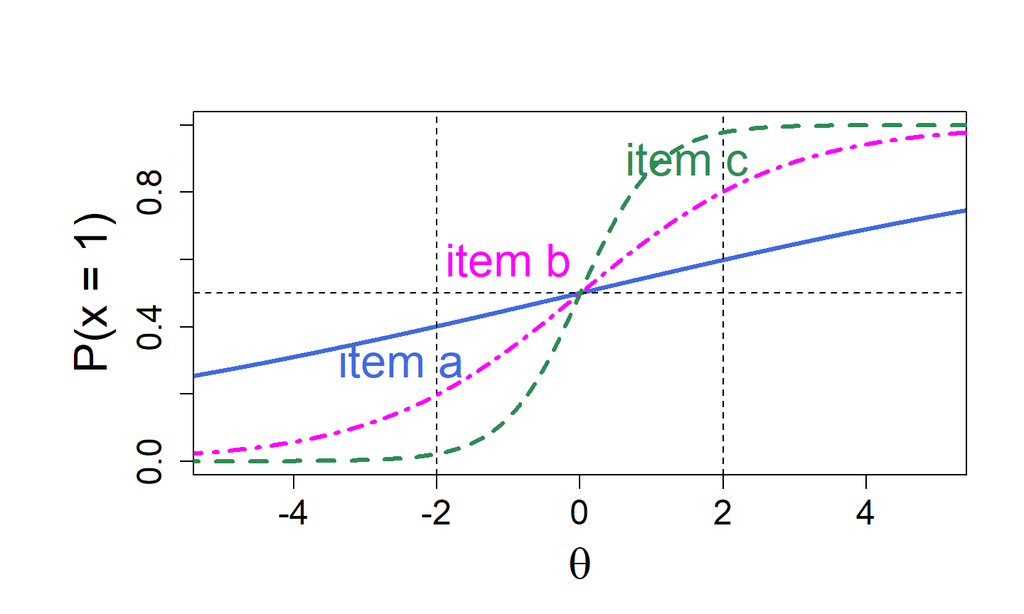

## Information function

### Item Information Function

\(I_i(\theta) = a^2 P_i(\theta)(1- P_i(\theta))\)

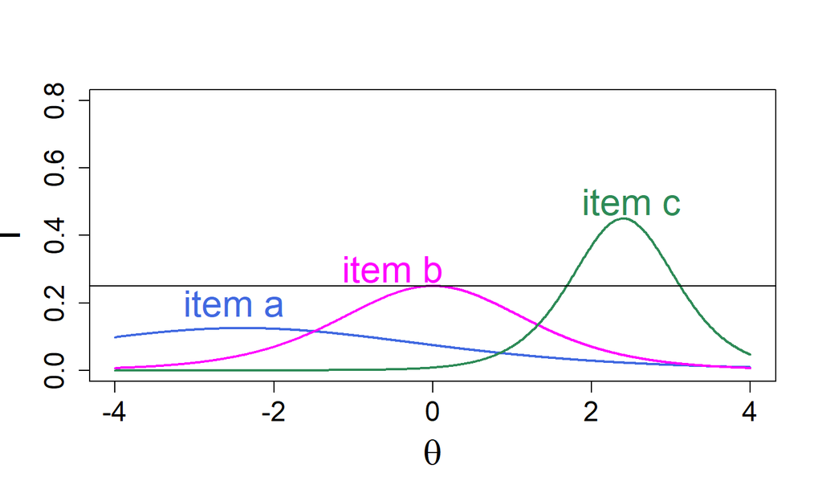

[output not shown]

### Test Information Function

\(I(\theta) = \displaystyle \sum_{i = 1}^{n} I_i(\theta)\)

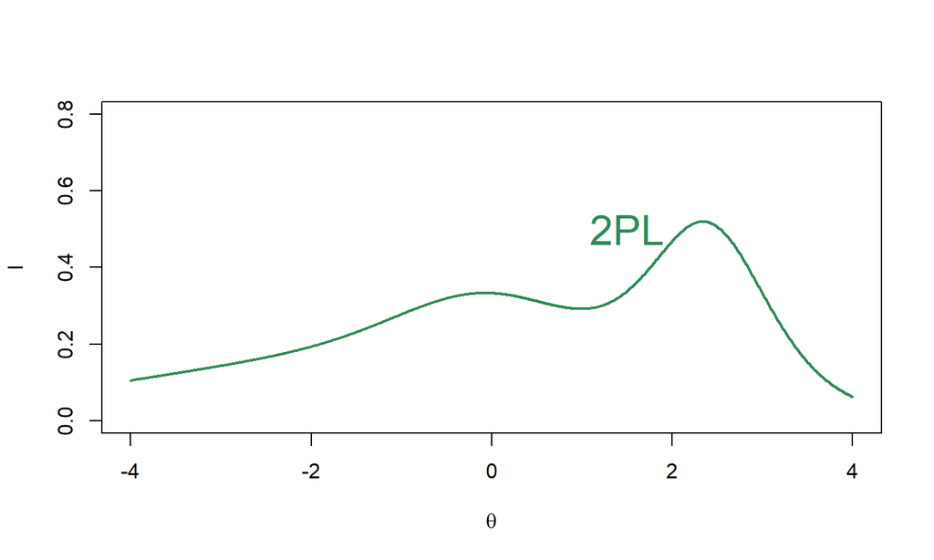

## Creare forme brevi

Dati i seguenti 10 item:

|  | b | a | IIF |
| --- | --- | --- | --- |
| item 1 | -0.67 | 0.71 | 0.11 |
| item 2 | 0.50 | 1.19 | 0.26 |
| item 3 | -2.43 | 0.25 | 0.01 |
| item 4 | 2.12 | 1.98 | 0.16 |
| item 5 | 1.72 | 0.38 | 0.03 |
| item 6 | -2.28 | 1.62 | 0.13 |
| item 7 | 0.64 | 0.50 | 0.06 |
| item 8 | -2.51 | 1.68 | 0.10 |
| item 9 | -0.66 | 0.44 | 0.04 |
| item 10 | 0.72 | 0.33 | 0.03 |

Si vuole selezionare una forma breve a 5 item. Come fare?

## Strategia classica

\(item = max(I(\theta))\)

Seleziona i 5 item che forniscono l’informatività maggiore

|  | b | a | IIF |
| --- | --- | --- | --- |
| item 2 | 0.50 | 1.19 | 0.26 |
| item 4 | 2.12 | 1.98 | 0.16 |
| item 6 | -2.28 | 1.62 | 0.13 |
| item 1 | -0.67 | 0.71 | 0.11 |
| item 8 | -2.51 | 1.68 | 0.10 |
| item 7 | 0.64 | 0.50 | 0.06 |
| item 9 | -0.66 | 0.44 | 0.04 |
| item 5 | 1.72 | 0.38 | 0.03 |
| item 10 | 0.72 | 0.33 | 0.03 |
| item 3 | -2.43 | 0.25 | 0.01 |

## Strategie basate su \(\theta\) target

### Cluster

\(item = max(I(\theta_k))\) dove \(k\) è il cluster

Seleziona i 5 item maggiormente informativi per 5 \(\theta\) target (i.e., i centroidi dei cluster):

| item | theta target | IIF |
| --- | --- | --- |
| item6 | -1.70 | 0.53 |
| item8 | -0.80 | 0.14 |
| item1 | -0.05 | 0.12 |
| item2 | 0.75 | 0.35 |
| item4 | 1.69 | 0.82 |

### Gruppi

\(item = max(I(\theta_g))\) dove \(g\) è il gruppo

Seleziona i 5 item maggiormente informativi per 5 \(\theta\) target (i.e., i \(\theta\) che dividono il tratto latente in 5 intervalli)

| item | theta target | IIF |
| --- | --- | --- |
| item8 | -3.07 | 0.57 |
| item6 | -1.54 | 0.47 |
| item2 | -0.01 | 0.32 |
| item4 | 1.53 | 0.71 |
| item7 | 3.06 | 0.04 |

## Metodo

## Studio di simulazione

Classica vs. Cluster vs. Gruppi vs. Random

1000 Soggetti:

- \({\displaystyle {\mathcal {N}}\{0,1\}}\)
- \(Beta(1, 100)\) (trasformata linearmente per ottenere valori negativi)
- \({\displaystyle {\mathcal {U}}\{-3,3\}}\)

100 Item:

\(b = {\displaystyle {\mathcal {U}}\{-3,3\}}\)

\(a = {\displaystyle {\mathcal {U}}\{.40,2\}}\)

Obiettivo \(\rightarrow\) creare forme brevi per ridurre da 100 item a 90, 70, 50, 30, 10 item

La random estrae 10 combinazioni di item per ogni numerosità

## Il tratto latente

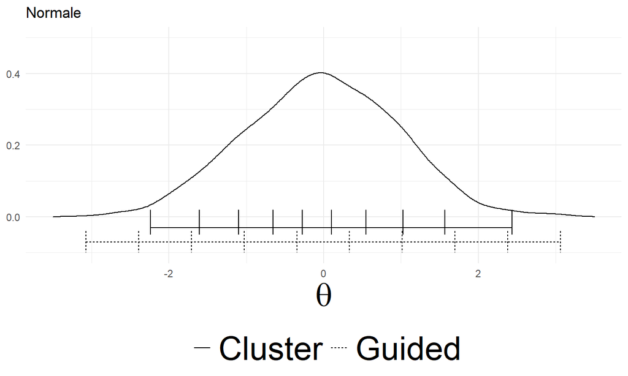

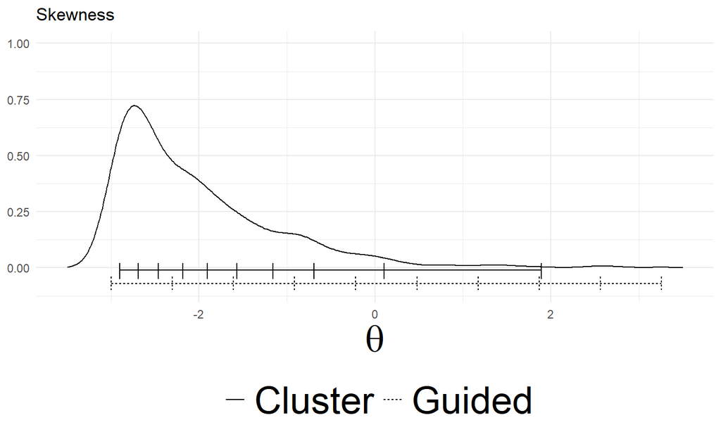

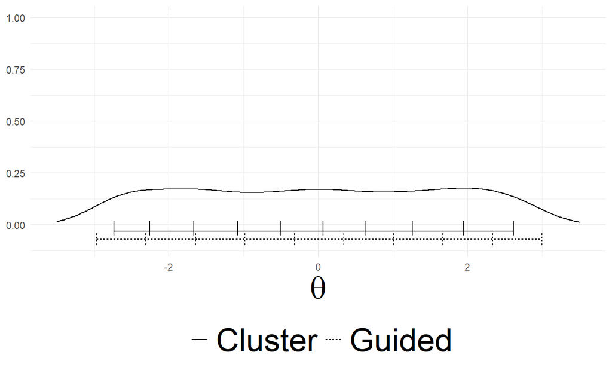

## Information & Reliability

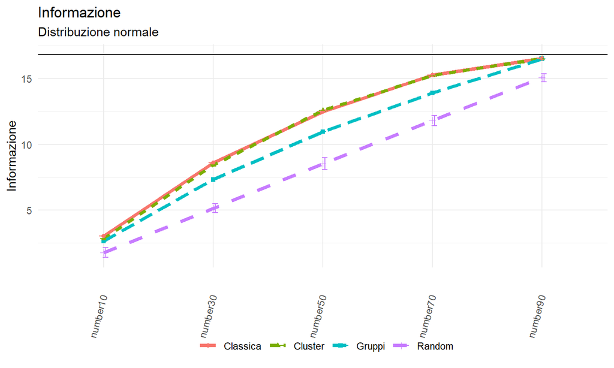

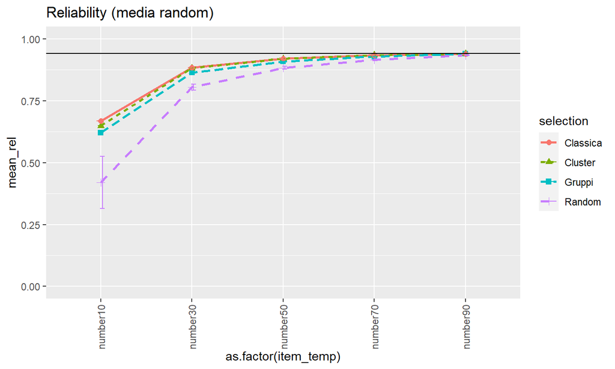